# Scraping Websites

There are times when we need to scrape some data from a website to use in our analyses. In a perfect world, the provider of the data would provide a csv or json download but let’s face it… we do not live in a perfect world and often data that is posted to the internet is done by people who really do not care about subseqent use by others (else they would have made it easy to use rather than just showing it).

Here is a quick tutorial on one method I use to do this.

## Necessary Resources

For this example, I’m going to use the `rvest` and `dplyr` libraries to scrape a USDA page for county FIPS codes[^1] for all the counties in Virginia.

```r
if( !("dplyr" %in% installed.packages()) ) {
  install.packages("tidyverse")
}
if( !("rvest" %in% installed.packages() )  ) {
  install.packages("rvest")
}

library( rvest )
library( tidyverse )
```

To start, grab the URL of the page you are intending to scrape. This one is a pretty straight forward structure.

[figure not shown]

USDA Website

```r
url <- "https://www.nrcs.usda.gov/wps/portal/nrcs/detail/?cid=nrcs143_013697"
page <- read_html(url)
page
```

```
{html_document}
<html xmlns="http://www.w3.org/1999/xhtml" lang="en">
[1] <head>\n<meta http-equiv="X-UA-Compatible" content="IE=edge,chrome=1">\n< ...
[2] <body style="">\t\t \t\t           \r\n<a href="#actualContent" accesskey ...
```

Now we can use some tidy methods to get to the components. We will go through the nodes and grab the “body” component then show the children in the body.

```r
page %>%
  html_node("body") %>%
  html_children()
```

```
{xml_nodeset (2)}
[1] <a href="#actualContent" accesskey="c" style="position:absolute;color:#9B ...
[2] <table id="wptheme_pageArea" summary="This table is used for page layout" ...
```

The page has broken up into compoennts, of which we can search. To figure out what parts we are going to grab data from, we need to look at the raw code in the document. Your browser can do this and you’ll have to manually look through the components. Here is what this page looks like.

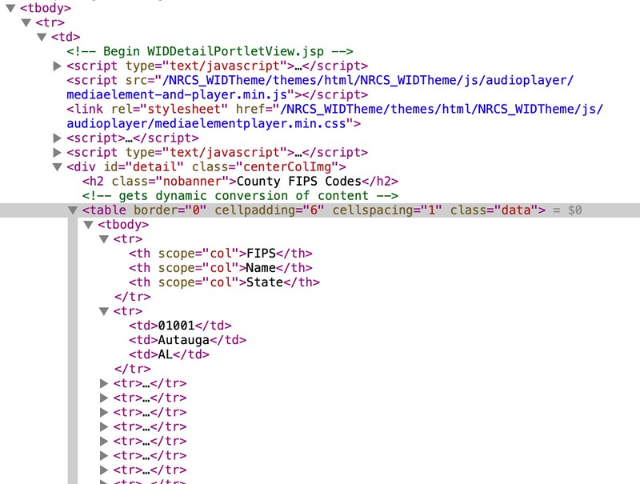

HTML Content

Here you notice that the table that contains the data we are interested in looking at has a class equal to `data`. We can grab all the `table` components from the page and look to see which one we are interested in.

```r
page %>%
  xml_find_all(".//table")
```

```
{xml_nodeset (26)}
 [1] <table id="wptheme_pageArea" summary="This table is used for page layout ...
 [2] <table class="layoutRow" cellpadding="0" cellspacing="0" width="100%"><t ...
 [3] <table summary="This table is used for page layout" class="themetable" b ...
 [4] <table class="layoutRow" cellpadding="0" cellspacing="0" width="100%"><t ...
 [5] <table summary="This table is used for page layout" width="100%" border= ...
 [6] <table class="layoutRow" cellpadding="0" cellspacing="0" width="100%"><t ...
 [7] <table summary="This table is used for page layout" class="themetable" b ...
 [8] <table summary="This table is used for page layout" width="100%" border= ...
 [9] <table class="layoutRow" cellpadding="0" cellspacing="0" width="100%"><t ...
[10] <table summary="This table is used for page layout" class="themetable" b ...
[11] <table summary="This table is used for page layout" width="100%" border= ...
[12] <table summary="This table is used for page layout" width="100%" border= ...
[13] <table summary="This table is used for page layout" width="100%" border= ...
[14] <table summary="This table is used for page layout" width="100%" border= ...
[15] <table summary="This table is used for page layout" width="100%" border= ...
[16] <table summary="This table is used for page layout" width="100%" border= ...
[17] <table summary="This table is used for page layout" width="100%" border= ...
[18] <table summary="This table is used for page layout" class="themetable" b ...
[19] <table summary="This table is used for page layout" class="themetable" b ...
[20] <table summary="This table is used for page layout" width="100%" border= ...
...
```

There are 26 total tables on this page! But it looks like the first 20 do not contain the table of interest. Here are the last ones.

```r
page %>%
  xml_find_all(".//table") %>%
  tail()
```

```
{xml_nodeset (6)}
[1] <table border="0" cellpadding="6" cellspacing="1" class="data"><tbody>\n< ...
[2] <table class="layoutRow" cellpadding="0" cellspacing="0" width="100%"><tr ...
[3] <table summary="This table is used for page layout" class="themetable" bo ...
[4] <table summary="This table is used for page layout" class="themetable" bo ...
[5] <table summary="This table is used for page layout" width="100%" border=" ...
[6] <table summary="This table is used for page layout" class="themetable" bo ...
```

And we see that the data table is the one with `class="data"`, that differentiates it from the rest. We can use this to pull out just the table with the attribute `class = "data"` using xml search techniques. The syntax is a bit odd as it is based upon xml search syntax but you can get the notion.

```r
page %>%
  xml_find_all(".//table") %>%
  xml_find_all("//table[contains(@class, 'data')]")
```

```
{xml_nodeset (1)}
[1] <table border="0" cellpadding="6" cellspacing="1" class="data"><tbody>\n< ...
```

Now we can turn that table into a `data.frame` and format the columns appropriately[^2]

```r
page %>%
  xml_find_all(".//table") %>%
  xml_find_all("//table[contains(@class, 'data')]") %>%
  html_table( fill = TRUE ) %>%
  .[[1]] %>%
  mutate( Name = factor(Name), State = factor(State) ) -> raw_data

summary( raw_data)
```

```
      FIPS               Name          State
 Min.   : 1001   Washington:  32   TX     : 254
 1st Qu.:19046   Jefferson :  26   GA     : 159
 Median :30044   Franklin  :  25   VA     : 136
 Mean   :31573   Jackson   :  24   KY     : 120
 3rd Qu.:46136   Lincoln   :  24   MO     : 115
 Max.   :78030   Madison   :  20   KS     : 105
                 (Other)   :3081   (Other):2343
```

**PERFECT!!** Now, to pull the parts that are relevant to us, the ones from Virginia.

```r
raw_data %>%
  filter( State == "VA" ) %>%
  select(Name, FIPS) %>%
  droplevels()
```

| Name | FIPS |
| --- | --- |
| Accomack | 51001 |
| Albemarle | 51003 |
| Alleghany | 51005 |
| Amelia | 51007 |
| Amherst | 51009 |
| Appomattox | 51011 |
| Arlington | 51013 |
| Augusta | 51015 |
| Bath | 51017 |
| Bedford | 51019 |

[output cut: 126 more lines]

And there you go.